# Trabajo con textos en R

Autor/a

Santiago García Sánchez

## Librerías

Se cargan todas las librerías necesarias:

**Código**

```r
#Trabajo con textos
library(pdftools) #Importar PDFs
library(tidytext) #Varias funciones
library(corpus) #Tokenizacion / Lematización
library(stopwords) #Palabras vacías
library(quanteda) #Matrices

#Gráficos
library(ggwordcloud) #Nubes
library(igraph) #Diagramas de red
library(ggraph) #Diagramas de red

#Varios
library(tidyverse)
```

## Importar archivos PDF

Para importar un archivo con extensión .pdf, se puede recurrir a la función *pdf_text()* del paquete **pdftools**. El objeto resultante es del tipo *character*, con una longitud equivalente al numero de páginas del archivo original.

En el siguiente ejemplo, se importa un archivo y se muestran sus primeras dos páginas:

**Código**

```r
#Importar un archivo
pdf_importado <- pdftools::pdf_text("2001_una_odisea_espacial.pdf")

head(pdf_importado, n = 2) #Dos primeras páginas
```

```
[1] "      2001:\nUna Odisea Espacial\n    ARTHUR C. CLARKE\n"
[2] "                          I – NOCHE PRIMITIVA\n\n\n                        1 - El camino de la extinción\n\n\n    La sequía había durado ya diez millones de años, y el reinado de los\nterribles saurios tiempo ha que había terminado. Aquí en el ecuador, en el\ncontinente que había de ser conocid…
```

### Importar múltiples archivos

Para evitar cargar cada archivo por separado, se puede crear una función como la que se muestra a continuación, la cual busca todos los elementos con extensión .pdf en una ruta y los importa al programa:

**Código**

```r
#Importar todos los archivos de una carpeta

  #Función nueva
importar_pdf <- function(ruta){
  setwd(ruta)
  pdf_archivos <- list.files(pattern = "pdf$") #Busca todos los archivos .pdf
  lista <- lapply(pdf_archivos, pdf_text)
  names(lista) <- pdf_archivos #Les asigna su nombre respectivo
  return(lista)
}

  #Ejemplo
pdfs_importados <- importar_pdf("Mis PDF")

summary(pdfs_importados)
```

```
                                Length Class  Mode
Calidoscopio.pdf                 9     -none- character
El color que cayo del cielo.pdf 26     -none- character
Un escandalo en Bohemia.pdf     18     -none- character
```

## Preprocesamiento de los datos

Antes de poder trabajar con la información provista por los documentos, generalmente se deberá realizar una serie de tareas para limpiar los textos y darles un formato apropiado.

Para mostrar cómo llevar estos procesos a la práctica, se utilizará a modo de ejemplo el siguiente texto:

Cuando el que viaja por el norte de la región central de Massachusetts se equivoca de dirección al llegar al cruce de la carretera de Aylesbury nada más pasar Dean’s Corners, verá que se adentra en una extraña y apenas poblada comarca. El terreno se hace más escarpado y las paredes de piedra cubiertas de maleza van encajonando cada vez más el sinuoso camino de tierra. Los árboles de los bosques son allí de unas dimensiones excesivamente grandes, y la maleza, las zarzas y la hierba alcanzan una frondosidad rara vez vista en las regioneshabitadas.

Autor: H.P. Lovecraft

### Limpieza inicial

Mediante la función *gsub()* se pueden eliminar cadenas de texto no deseadas. También es posible corregir algunos errores que puedan aparecer al importar los archivos pdf.

**Código**

```r
texto_prueba <- "
Cuando el que viaja por el norte de la región central de Massachusetts
se equivoca de dirección al llegar al cruce de la carretera
de Aylesbury nada más pasar Dean's Corners, verá que se adentra
en una extraña y apenas poblada comarca. El terreno se hace más
escarpado y las paredes de piedra cubiertas de maleza van
encajonando cada vez más el sinuoso camino de tierra. Los árboles
de los bosques son allí de unas dimensiones excesivamente
grandes, y la maleza, las zarzas y la hierba alcanzan una
frondosidad rara vez vista en las regioneshabitadas.
\n
Autor: H.P. Lovecraft
"

texto_prueba <- texto_prueba %>%
  gsub("Autor: H.P. Lovecraft","",.) %>%
  gsub("\n","",.) %>%
  gsub("regioneshabitadas","regiones habitadas",.)

texto_prueba
```

```
[1] "Cuando el que viaja por el norte de la región central de Massachusetts se equivoca de dirección al llegar al cruce de la carretera de Aylesbury nada más pasar Dean's Corners, verá que se adentra en una extraña y apenas poblada comarca. El terreno se hace más escarpado y las paredes de piedra cu…
```

### Tokenización

A continuación, se lleva a cabo el proceso conocido como *tokenización* o segmentación. Los textos deben ser divididos en unidades (tókenes).

Una alternativa para realizar esta tarea es la función *text_tokens()* del paquete **corpus**. Esta función toma un objeto (o lista de objetos) del tipo *character* y devuelve una lista (o lista de listas) con sus palabras por separado. Además, todo el texto es automáticamente transformado a minúsculas:

**Código**

```r
corpus::text_tokens(texto_prueba)
```

```
[[1]]
  [1] "cuando"        "el"            "que"           "viaja"
  [5] "por"           "el"            "norte"         "de"
  [9] "la"            "región"        "central"       "de"
 [13] "massachusetts" "se"            "equivoca"      "de"
 [17] "dirección"     "al"            "llegar"        "al"
 [21] "cruce"         "de"            "la"            "carretera"
 [25] "de"            "aylesbury"     "nada"          "más"
 [29] "pasar"         "dean's"        "corners"       ","
 [33] "verá"          "que"           "se"            "adentra"
 [37] "en"            "una"           "extraña"       "y"
 [41] "apenas"        "poblada"       "comarca"       "."
 [45] "el"            "terreno"       "se"            "hace"
 [49] "más"           "escarpado"     "y"             "las"
 [53] "paredes"       "de"            "piedra"        "cubiertas"
 [57] "de"            "maleza"        "van"           "encajonando"
 [61] "cada"          "vez"           "más"           "el"
 [65] "sinuoso"       "camino"        "de"            "tierra"
 [69] "."             "los"           "árboles"       "de"
 [73] "los"           "bosques"       "son"           "allí"
 [77] "de"            "unas"          "dimensiones"   "excesivamente"
 [81] "grandes"       ","             "y"             "la"
 [85] "maleza"        ","             "las"           "zarzas"
 [89] "y"             "la"            "hierba"        "alcanzan"
 [93] "una"           "frondosidad"   "rara"          "vez"
 [97] "vista"         "en"            "las"           "regiones"
[101] "habitadas"     "."
```

Otra alternativa es la función *unnest_tokens()* del paquete **tidytext**. Esta función toma un objeto de clase *tibble* y devuelve otro en el que cada fila corresponde a una palabra.

**Código**

```r
tibble(texto_prueba) %>% #Convertir a objeto tibble
    tidytext::unnest_tokens(output = palabra, input = texto_prueba)
```

| palabra |
| --- |
| cuando |
| el |
| que |
| viaja |
| por |
| el |
| norte |
| de |
| la |
| región |

[output cut: 86 more lines]

### Lematización y *stemming*

Un paso opcional consiste en aplicar un algoritmo de lexematización o de lematización, con el objetivo de transformar todas las variante de una palabra a una único elemento “base”.

#### Stemming / lexematización

La función *text_tokens()* posee un una opción incorporada para realizar *stemming*, utilizando los algoritmos de un lenguaje de programación llamado [*Snowball*](https://snowballstem.org/).

**Código**

```r
corpus::text_tokens(texto_prueba, stemmer = "es")%>%
  as.data.frame(col.names ="palabra") #Se pasa a data frame para mejor visualización
```

| palabra |
| --- |
| cuand |
| el |
| que |
| viaj |
| por |
| el |
| nort |
| de |
| la |
| region |

[output cut: 92 more lines]

Una alternativa más compleja es recurrir a modelos ya entrenados, mediante el paquete [UDPipe](https://bnosac.github.io/udpipe/en/). En [este enlace](https://cran.r-project.org/web/packages/udpipe/vignettes/udpipe-annotation.html) se presenta una guía para ello.

#### Lematización

La función *text_tokens()* mostrada anteriormente también permite utilizar una función personalizada para realizar *stemming* o lematización. De esta manera, es posible recurrir a un diccionario de lemas. Los autores del paquete *corpus* [recomiendan](https://corpustext.com/articles/stemmer.html) los diccionarios creados por Michal Měchura, disponibles para su descarga en [GitHub](https://github.com/michmech/lemmatization-lists).

Estos diccionarios consisten en dos columnas: la primera contiene los lemas (por ejemplo: “amigo”) y la segunda todos los términos derivados de éstos (“amiga”, “amigos”, “amigas”). Al tener un formato .txt, es fácil editarlos y añadir o quitar palabras.

**Código**

```r
#Se importa un diccionario (descargado de GitHub)
lematizacion <- read_table2("lemmatization-es.txt"
                            #Si no se ven correctamente los textos, usar esta opción:
                            #, locale = locale(encoding = "ISO-8859-1")
                            )


#Se crea una función personalizada (ver documentación del paquete Corpus)
names(lematizacion) <- c("stem", "term")

stem_list <- function(term) {
  i <- match(term, lematizacion$term)
  if (is.na(i)) {
    stem <- term
  } else {
    stem <- lematizacion$stem[[i]]
  }
  stem}

#Se aplica al texto
text_tokens(texto_prueba, stemmer = stem_list)%>%
  as.data.frame(col.names ="palabra") #Se pasa a data frame para mejor visualización
```

| palabra |
| --- |
| cuando |
| el |
| que |
| viajar |
| por |
| el |
| norte |
| de |
| el |
| región |

[output cut: 92 more lines]

### Palabras vacías

El paquete **stopwords** ofrece distintas listas de palabras vacías, en varios idiomas:

**Código**

```r
stopwords::stopwords_getsources()
```

```
[1] "snowball"      "stopwords-iso" "misc"          "smart"
[5] "marimo"        "ancient"       "nltk"          "perseus"
```

Para visualizar las palabras, se usa la función *get_stopwords()* del paquete **tidytext** (se necesita también el paquete **stopwords**). En este ejemplo se recurre a la lista *Stopwords ISO*, que contiene más de 700 palabras frecuentes en español.

**Código**

```r
tidytext::get_stopwords(language = "es", source = "stopwords-iso")
```

| word | lexicon |
| --- | --- |
| 0 | stopwords-iso |
| 1 | stopwords-iso |
| 2 | stopwords-iso |
| 3 | stopwords-iso |
| 4 | stopwords-iso |
| 5 | stopwords-iso |
| 6 | stopwords-iso |
| 7 | stopwords-iso |
| 8 | stopwords-iso |
| 9 | stopwords-iso |

[output cut: 722 more lines]

Es posible combinar varias listas de palabras o crear una lista personalizada añadiendo palabras propias:

**Código**

```r
lista_stopwords <- c(get_stopwords(language = "es", source = "stopwords-iso")$word, "vos", "sos", "hacés") #Se añaden 3 palabras

lista_stopwords %>%
  as.data.frame(col.names = "palabra")
```

| . |
| --- |
| 0 |
| 1 |
| 2 |
| 3 |
| 4 |
| 5 |
| 6 |
| 7 |
| 8 |
| 9 |

[output cut: 725 more lines]

Para eliminar estas palabras de los documentos, se usa la función *filter()* del paquete **dplyr** (importado como parte del *tidyverse*).

**Código**

```r
corpus::text_tokens(texto_prueba) %>%
  as.data.frame(col.names = "palabra") %>% #Se convierte a data frame para poder filtrar
  dplyr::filter(!palabra %in% lista_stopwords) #Se mantienen las palabras que NO estén en "lista_stopwords"
```

| palabra |
| --- |
| viaja |
| norte |
| región |
| central |
| massachusetts |
| equivoca |
| dirección |
| llegar |
| cruce |
| carretera |

[output cut: 38 more lines]

### Otra limpieza

La función *filter()* también puede utilizarse para eliminar otros elementos no deseados de los textos, como caracteres de alfabetos distintos, números y signos de puntuación. Utilizando la función *grepl()* se evalúa si una fila cumple una determinada condición, para luego eliminar aquellas que devuelvan el valor FALSE. A continuación se muestra un ejemplo.

**Código**

```r
texto_sin_limpiar <- "123, esto es un texto normal, このテキストは日本語です. "
texto_sin_limpiar
```

```
[1] "123, esto es un texto normal, このテキストは日本語です. "
```

**Código**

```r
texto_limpio <- corpus::text_tokens(texto_sin_limpiar) %>%
  as.data.frame(col.names ="palabra")  %>%
  filter(!palabra %in% lista_stopwords,
         grepl(pattern = "[\U0020-\U007F\U00A0-\U00FF]",palabra), #Se mantiene solo el alfabeto latino
            ##Ver https://jrgraphix.net/r/Unicode/ para más detalles
         nchar(palabra) >= 2, #Se mantiene solo palabras de más de dos caracteres (elimina signos de puntuación)
         !grepl(pattern = "[0-9]",palabra) #Se mantienen las palabras que NO sean números
         )

texto_limpio
```

| palabra |
| --- |
| texto |
| normal |

## Calcular estadísticas

Ahora se presentan dos maneras distintas de sintetizar la información provista por los textos: la frecuencia de términos y la estadística TF-IDF.

### Frecuencia de términos (TF)

Antes de calcular las estadísticas, se crea una función para realizar el preprocesamiento.

**Código**

```r
obtener_palabras <- function(texto, titulo){
  tibble(texto) %>%
  tidytext::unnest_tokens(output = palabra, input = texto) %>%
  dplyr::filter(!palabra %in% lista_stopwords,
         nchar(palabra) > 2,
         !grepl(pattern = "[0-9]",palabra)
         ) %>%
  mutate(titulo = titulo)
}
```

Para obtener la frecuencia de términos, se puede recurrir a la función *count()* del paquete **dplyr()**. Esta función también ordena las palabras de más a menos frecuente, si se especifica la opción *sort*.

**Código**

```r
palabras_pdf <- obtener_palabras(pdf_importado, "2001: Una odisea Espacial")

palabras_pdf %>%
  dplyr::count(palabra, sort = TRUE)
```

| palabra | n |
| --- | --- |
| bowman | 197 |
| podía | 188 |
| tierra | 185 |
| nave | 126 |
| floyd | 123 |
| hal | 113 |
| luz | 103 |
| luna | 96 |
| años | 93 |
| kilómetros | 89 |

[output cut: 9191 more lines]

### TF-IDF

La función *bind_tf_idf()* del paquete **tidytext** permite calcular la estadística TF-IDF. Para esto se requiere que el conjunto de datos tenga tres columnas:

- Una columna con un término por fila (“*palabra*” en este ejemplo).
- Una columna que indique a qué documento pertenece cada término (“*título*”).
- Una columna con la frecuencia absoluta de cada término (“*n*”).

La función añade tres columnas al conjunto de datos:

- **tf**: A pesar del nombre, en realidad es la frecuencia relativa del término en el documento y no la frecuencia absoluta.
- **idf**: El valor de IDF de cada término, siendo 0 si éste aparece en todos los documentos.
- **tf-idf**: El valor de TF-IDF de cada término (producto de las dos columnas anteriores).

**Código**

```r
#Se le aplica la función "obtener_palabras" a cada pdf y se los guarda en un único objeto
palabras_pdfs = c()
for (texto in 1:length(pdfs_importados)) {
  palabras_pdfs <- dplyr::bind_rows(palabras_pdfs, obtener_palabras(pdfs_importados[[texto]], names(pdfs_importados[texto])) )
}

#Se calcula TF-IDF
palabras_pdfs_tfidf = palabras_pdfs %>%
  group_by(titulo) %>% #Se agrupa por archivo
  count(palabra) %>%
  tidytext::bind_tf_idf(palabra, titulo, n) %>% #Se calcula TF-IDF
  arrange(desc(tf_idf)) #Se ordena de mayor a menor valor de TF-IDF

palabras_pdfs_tfidf
```

| titulo | palabra | n | tf | idf | tf_idf |
| --- | --- | --- | --- | --- | --- |
| Calidoscopio.pdf | hollis | 52 | 0.0406250000 | 1.0986123 | 4.463112e-02 |
| El color que cayo del cielo.pdf | ammi | 85 | 0.0172029953 | 1.0986123 | 1.889942e-02 |
| Un escandalo en Bohemia.pdf | holmes | 56 | 0.0160183066 | 1.0986123 | 1.759791e-02 |
| El color que cayo del cielo.pdf | nahum | 70 | 0.0141671726 | 1.0986123 | 1.556423e-02 |
| Calidoscopio.pdf | lespere | 16 | 0.0125000000 | 1.0986123 | 1.373265e-02 |
| Calidoscopio.pdf | applegate | 15 | 0.0117187500 | 1.0986123 | 1.287436e-02 |
| Calidoscopio.pdf | stimson | 15 | 0.0117187500 | 1.0986123 | 1.287436e-02 |
| El color que cayo del cielo.pdf | pozo | 49 | 0.0099170208 | 1.0986123 | 1.089496e-02 |
| Calidoscopio.pdf | stone | 11 | 0.0085937500 | 1.0986123 | 9.441199e-03 |
| Calidoscopio.pdf | cayendo | 9 | 0.0070312500 | 1.0986123 | 7.724618e-03 |

[output cut: 5431 more lines]

### Gráficos

Una forma habitual de graficar las palabras más frecuentes de un texto es mediante una nube de palabras. Esto se puede hacer mediante los paquetes **ggplot2** y **ggwordcloud**:

**Código**

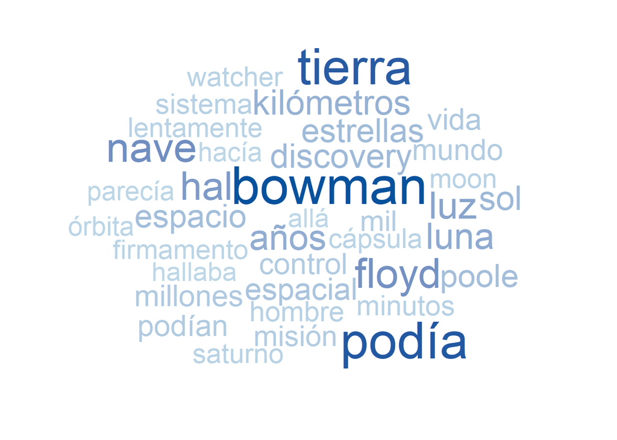

```r
palabras_pdf %>%
  count(palabra) %>%
  filter(n >= 50) %>%
  ggplot() +
    aes(label = palabra, #Texto a mostrar
        size = n, #El tamaño es dado por la frecuencia absoluta
        color = n) + #La intensidad del color es dada por la frecuencia absoluta
    ggwordcloud::geom_text_wordcloud(eccentricity = 1) + #Forma de la nube
    scale_size_area(max_size = 15) + #Tamaño del texto
    scale_color_gradient(low = "#bdd7e7", #Color para la menor frecuencia
                         high = "#08519c") + #Color para la mayor frecuencia
    theme_minimal()
```

También se puede hacer que el tamaño de las palabras y la intensidad de su color correspondan a medidas distintas. Por ejemplo, el tamaño puede corresponder al valor TF-IDF mientras que la intensidad del color indica la frecuencia de términos:

**Código**

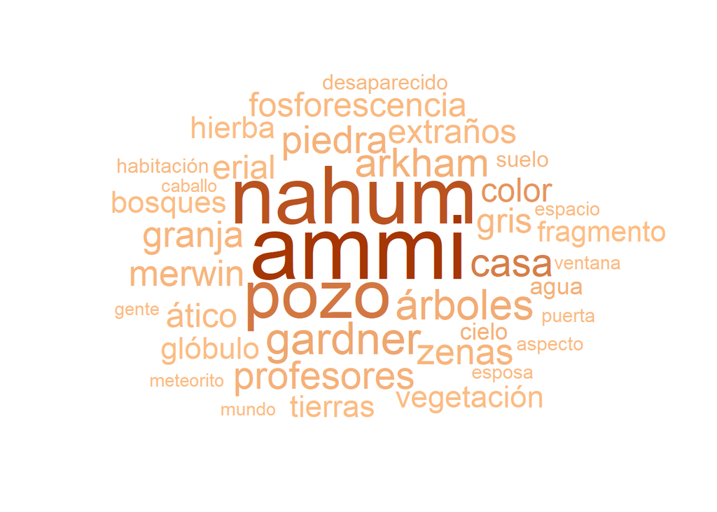

```r
palabras_pdfs_tfidf %>%
  filter(titulo == "El color que cayo del cielo.pdf", #Se selecciona un libro específico
         tf_idf > 0,
         n >= 9) %>%
  ggplot() +
    aes(label = palabra,
        size = tf_idf, #El tamaño es dado por el valor TF-IDF
        color = n) + #La intensidad del color es dada por la frecuencia absoluta
    geom_text_wordcloud(eccentricity = 1) +
    scale_size_area(max_size = 22) +
    scale_color_gradient(low = "#fdbe85",
                         high = "#a63603") +
    theme_minimal()
```

Otra alternativa que se utiliza a menudo es un gráfico de dispersión, donde el eje horizontal corresponde a las palabras y el eje vertical a su frecuencia. Se añaden etiquetas a los puntos con la función *geomtext()* de **ggplot2**.

**Código**

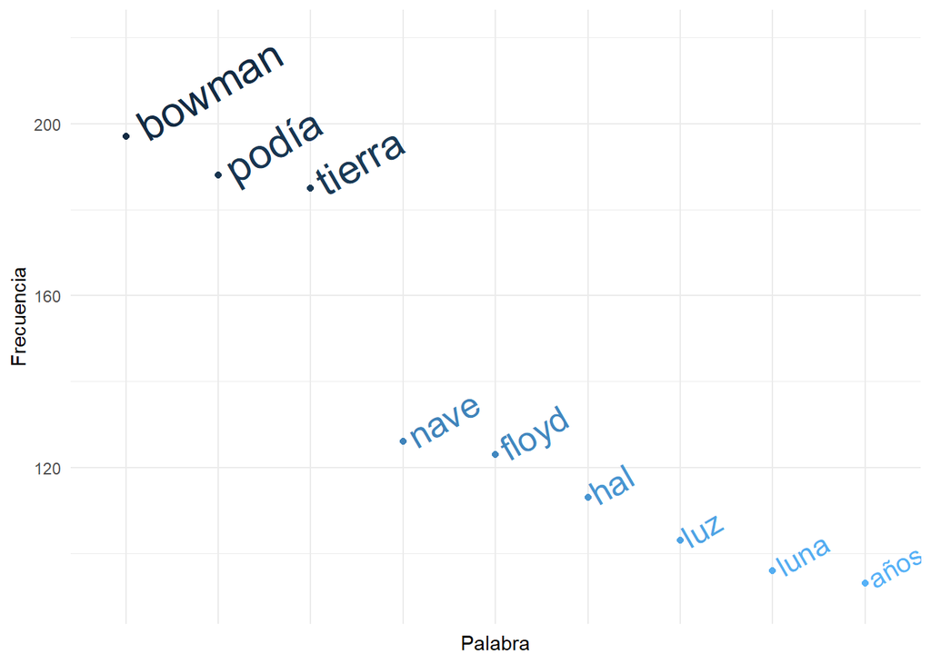

```r
palabras_pdf %>%
  count(palabra, sort = T) %>%
  filter(n >= 90) %>%
  ggplot(
    aes(x= reorder(palabra,-n),
      y=n)
      ) +
  geom_text(aes(size=n, #Se grafican las palabras
                label=palabra,
                angle=30,
                color=-n),
            hjust=-.1,
            show.legend = F) +
  scale_size_continuous(range=c(5,8)) + #Tamaños de las palabras
  scale_fill_gradient(low = "#bdd7e7",high = "#08519c") +
  geom_point(aes(color=-n)) + #Se añaden los puntos
  ylim(c(90, 220)) +
  labs(x = "Palabra", y = "Frecuencia") +
  theme_minimal() +
  theme(axis.text.x = element_blank(),
        axis.ticks.x= element_blank(),
        legend.position='none')
```

Finalmente, se pueden utilizar gráficos más tradicionales, como por ejemplo un gráfico de barras:

**Código**

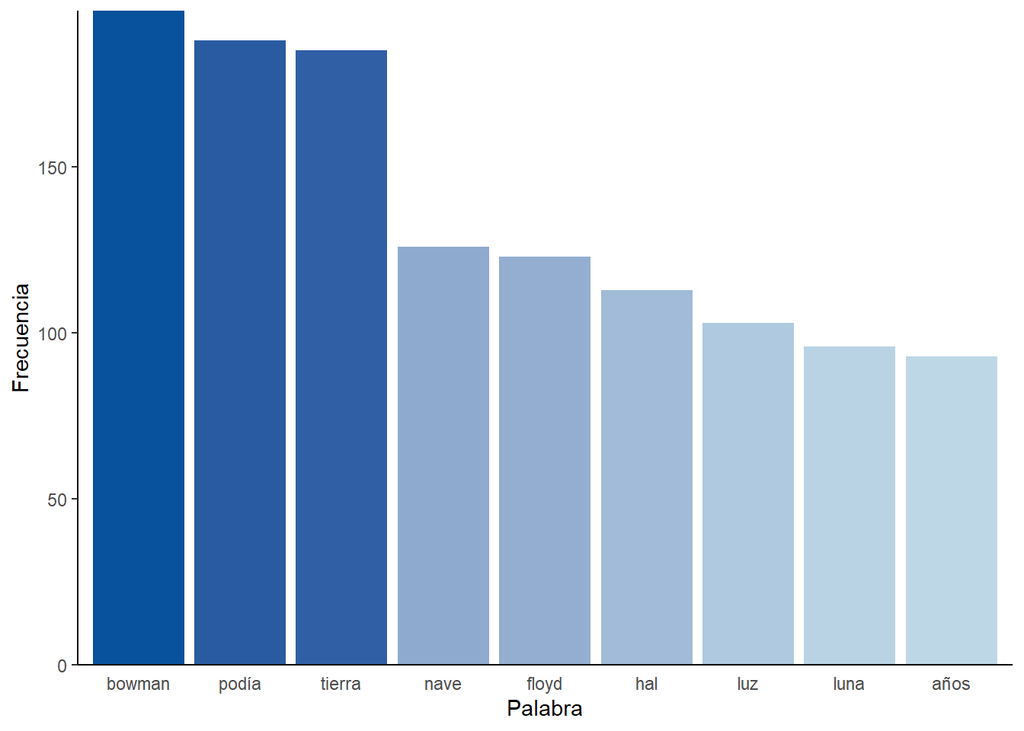

```r
palabras_pdf %>%
  count(palabra, sort = T) %>%
  filter(n >= 90) %>%
  ggplot(
    aes(x= reorder(palabra,-n),
      y=n)
      ) +
  geom_bar(stat="identity", aes(fill=n)) +
  scale_y_continuous(expand = c(0, 0)) +
  scale_fill_gradient(low = "#bdd7e7",high = "#08519c") +
  labs(x="Palabra", y="Frecuencia") +
  theme_classic() +
  theme(legend.position = "none",
        axis.ticks.x= element_blank())
```

## N-gramas

Trabajar con n-gramas es muy similar a trabajar con palabras individuales (unigramas). En esta sección, se verán ejemplos para n-gramas con $n=2$ (bigramas), pero todo lo visto puede ser generalizado para n-gramas de mayores dimensiones.

### Construcción

La función *unnest_tokens()* permite también obtener los bigramas de un texto, especificando las opciones *token = “ngrams”* y *n = 2*. Este último argumento permite también construir n-gramas con n > 2 (por ejemplo, al especificar *n = 3* se obtendrían trigramas).

**Código**

```r
tibble(pdf_importado) %>%
  tidytext::unnest_tokens(output = bigrama, input = pdf_importado, token = "ngrams", n = 2)
```

| bigrama |
| --- |
| 2001 una |
| una odisea |
| odisea espacial |
| espacial arthur |
| arthur c |
| c clarke |
| i noche |
| noche primitiva |
| primitiva 1 |
| 1 el |

[output cut: 9990 more lines]

Para realizar el preprocesamiento visto anteriormente para palabras individuales, puede recurrirse a las funciones *separate()* y *unite()* del paquete **tidyr**, como se ve en el siguiente ejemplo:

**Código**

```r
bigramas_pdf <- tibble(pdf_importado) %>%
  tidytext::unnest_tokens(output = bigrama,
                          input = pdf_importado,
                          token = "ngrams",
                          n = 2) %>%
  tidyr::separate(bigrama, c("palabra1", "palabra2"), sep = " ") %>% #Se separa el bigrama en palabras individuales
    filter(nchar(palabra1) > 2,
           nchar(palabra2) > 2,
           !palabra1 %in% lista_stopwords,
           !palabra2 %in% lista_stopwords,
           !grepl(pattern = "[0-9]",palabra1),
           !grepl(pattern = "[0-9]",palabra2)
           ) %>%
  tidyr::unite(bigrama, palabra1,palabra2, sep = " ") #Se vuelve a unir el bigrama

bigramas_pdf
```

| bigrama |
| --- |
| odisea espacial |
| espacial arthur |
| noche primitiva |
| diez millones |
| terribles saurios |
| terreno baldío |
| podía medrar |
| esperar sobrevivir |
| hombres mono |
| ende medrando |

[output cut: 7936 more lines]

### Estadísticas

Las mismas medidas que se calcularon para los unigramas son válidas para bigramas. Para obtener la frecuencia de términos, se utiliza nuevamente la función *count().*

**Código**

```r
bigramas_pdf %>%
  count(bigrama, sort=T)
```

| bigrama | n |
| --- | --- |
| moon watcher | 55 |
| mono humanoide | 29 |
| sistema solar | 23 |
| cápsula espacial | 21 |
| unidad a.e | 17 |
| doctor floyd | 16 |
| traje espacial | 15 |
| cámara reguladora | 14 |
| mil años | 14 |
| david bowman | 13 |

[output cut: 7134 more lines]

Del mismo modo, se vuelve a recurrir a *bind_tf_idf()* para calcular el valor TF-IDF de cada bigrama.

**Código**

```r
#Se define una función para obtener los bigramas
obtener_bigramas <- function(texto, titulo){
  tibble(texto) %>%
    tidytext::unnest_tokens(output = bigrama, input = texto, token = "ngrams", n = 2) %>%
    separate(bigrama, c("palabra1", "palabra2"), sep = " ") %>%
    filter(nchar(palabra1) > 2,
           nchar(palabra2) > 2,
           !palabra1 %in% lista_stopwords,
           !palabra2 %in% lista_stopwords,
           !grepl(pattern = "[0-9]",palabra1),
           !grepl(pattern = "[0-9]",palabra2)
           ) %>%
  unite(bigrama, palabra1,palabra2, sep = " ") %>%
  mutate(titulo = titulo)
}


#Se obtienen los bigramas de los textos importados
bigramas_pdfs = c()
for (texto in 1:length(pdfs_importados)) {
  bigramas_pdfs <- dplyr::bind_rows(bigramas_pdfs, obtener_bigramas(pdfs_importados[[texto]], names(pdfs_importados[texto])) )
}

#Se calcula la estadística TF-IDF
bigramas_pdfs_tfidf = bigramas_pdfs %>%
  group_by(titulo) %>% #Se agrupa por archivo
  count(bigrama) %>%
  tidytext::bind_tf_idf(bigrama, titulo, n) %>% #Se calcula TF-IDF
  arrange(desc(tf_idf)) #Se ordena de mayor a menor TF-IDF

bigramas_pdfs_tfidf
```

| titulo | bigrama | n | tf | idf | tf_idf |
| --- | --- | --- | --- | --- | --- |
| Un escandalo en Bohemia.pdf | sherlock holmes | 18 | 0.0217391304 | 1.0986123 | 0.0238828758 |
| Un escandalo en Bohemia.pdf | irene adler | 11 | 0.0132850242 | 1.0986123 | 0.0145950908 |
| Un escandalo en Bohemia.pdf | pabellón briony | 11 | 0.0132850242 | 1.0986123 | 0.0145950908 |
| Calidoscopio.pdf | mil kilómetros | 5 | 0.0129533679 | 1.0986123 | 0.0142307291 |
| Calidoscopio.pdf | pensó hollis | 3 | 0.0077720207 | 1.0986123 | 0.0085384375 |
| Calidoscopio.pdf | quince mil | 3 | 0.0077720207 | 1.0986123 | 0.0085384375 |
| Un escandalo en Bohemia.pdf | señor sherlock | 6 | 0.0072463768 | 1.0986123 | 0.0079609586 |
| Un escandalo en Bohemia.pdf | baker street | 5 | 0.0060386473 | 1.0986123 | 0.0066341322 |
| Un escandalo en Bohemia.pdf | godfrey norton | 5 | 0.0060386473 | 1.0986123 | 0.0066341322 |
| Calidoscopio.pdf | adiós hollis | 2 | 0.0051813472 | 1.0986123 | 0.0056922917 |

[output cut: 2309 more lines]

### Gráficos

Una forma de visualizar n-gramas es mediante diagramas de red. En este tipo de gráficos, cada nodo representa a una palabra, las cuáles pueden pertenecer a uno o varios bigramas.

En el siguiente ejemplo, dichos nodos se representan como círculos celestes, los cuales están unidos con flechas que indican el orden de las palabras en el bigrama. Las flechas adquieren una mayor transparencia a medida que el bigrama tiene una menor frecuencia en el texto.

**Código**

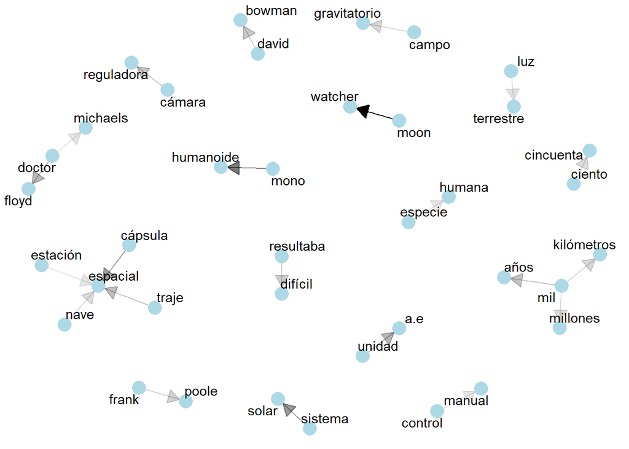

```r
bigramas_pdf %>%
  count(bigrama) %>%
  filter(n >= 7) %>%
  separate(bigrama, c("palabra1", "palabra2"), sep = " ") %>%
  igraph::graph_from_data_frame()  %>% #Crear la red
  ggraph::ggraph(layout = "fr") + #Graficar
  geom_edge_link(aes(edge_alpha = n), #Intensidad de la flecha depende de n
                 show.legend = FALSE,
                 arrow = grid::arrow(type = "closed", length = unit(.15, "inches")), #Estilo de las flechas
                 end_cap = circle(.07, 'inches')) +
  geom_node_point(color = "lightblue", size = 5) +
  geom_node_text(aes(label = name),
                 repel = TRUE,
                 point.padding = unit(0.1, "lines")) +
  theme_void()
```

En lugar de flechas, puede recurrirse simplemente a líneas. En este caso, tanto la intensidad como el grosor de la línea dependen de la frecuencia del bigrama conformado por las dos palabras que ésta une.

**Código**

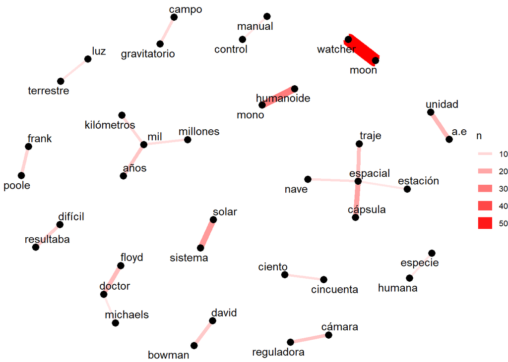

```r
bigramas_pdf %>%
  count(bigrama) %>%
  filter(n >= 7) %>%
  separate(bigrama, c("palabra1", "palabra2"), sep = " ") %>%
  graph_from_data_frame() %>%
  ggraph(layout = "fr") +
  geom_edge_link(aes(edge_alpha = n, edge_width = n), #Intensidad y grosor dependen de n
                 edge_colour = "red") +
  geom_node_point(size = 3) +
  geom_node_text(aes(label = name),
                 repel = TRUE,
                 point.padding = unit(0.1, "lines")) +
  theme_void() +
  theme(text = element_text(size = 10))
```

Una vez más, también es posible recurrir a gráficos más simples para visualizar las frecuencias de los n-gramas:

**Código**

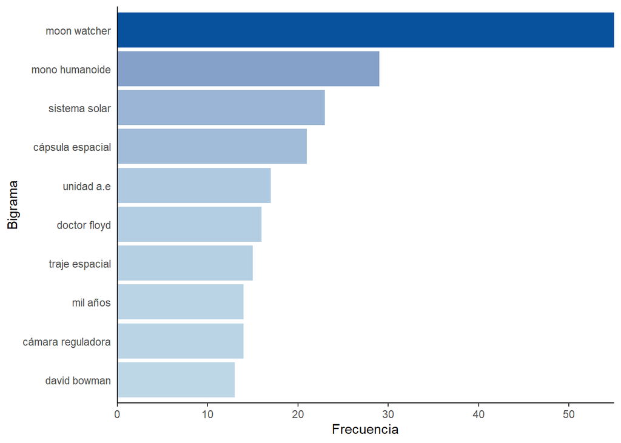

```r
bigramas_pdf %>%
  count(bigrama, sort = T) %>%
  filter(n >= 13) %>%
  ggplot(
    aes(x = reorder(bigrama,n),
      y = n)
      ) +
  geom_bar(stat="identity", aes(fill = n)) +
  scale_y_continuous(expand = c(0, 0)) +
  scale_fill_gradient(low = "#bdd7e7",high = "#08519c") +
  labs(x = "Bigrama", y = "Frecuencia") +
  theme_classic() +
  theme(legend.position = "none",
        axis.ticks.y= element_blank()) +
  coord_flip()
```

## Matrices DTM

En distintos contextos, puede ser necesario que los datos se presenten en el formato de una matriz de documentos-término (DTM). En este tipo de matrices, cada fila corresponde a un documento, mientras que cada columna corresponde a una palabra o n-grama. En cada celda, se suele colocar la frecuencia de dicha palabra o bigrama en el documento respectivo.

Hay múltiples paquetes que permiten trabajar con este formato, entre ellos **tm** y **quanteda**. En el siguiente ejemplo, se recurre a la función *cast_dfm()* para transformar un conjunto de datos en un objeto *dfm* del paquete **quanteda**.

**Código**

```r
matriz_palabras <- palabras_pdfs %>%
  group_by(titulo) %>%
  count(palabra) %>%
  arrange(palabra) %>%
  tidytext::cast_dfm(document=titulo, term=palabra, value=n)

head(matriz_palabras)
```

```
Document-feature matrix of: 3 documents, 4,644 features (60.95% sparse) and 0 docvars.
                                 features
docs                              abajo abalancé abandonaba abandonado
  Calidoscopio.pdf                    3        0          0          0
  El color que cayo del cielo.pdf     2        0          1          3
  Un escandalo en Bohemia.pdf         5        1          0          0
                                 features
docs                              abandonar abandonarlo abandonó abarcar abejas
  Calidoscopio.pdf                        0           0        0       0      0
  El color que cayo del cielo.pdf         1           1        0       0      1
  Un escandalo en Bohemia.pdf             0           0        1       1      0
                                 features
docs                              abierta
  Calidoscopio.pdf                      0
  El color que cayo del cielo.pdf       1
  Un escandalo en Bohemia.pdf           2
[ reached max_nfeat ... 4,634 more features ]
```

En lugar de la frecuencia de términos, en cada celda de la matriz puede utilizarse el valor TF-IDF:

**Código**

```r
matriz_palabras_tfidf <- palabras_pdfs_tfidf %>%
  arrange(palabra) %>%
  tidytext::cast_dfm(document=titulo, term=palabra, value=tf_idf)

head(matriz_palabras_tfidf)
```

```
Document-feature matrix of: 3 documents, 4,644 features (60.95% sparse) and 0 docvars.
                                 features
docs                              abajo     abalancé   abandonaba   abandonado
  Calidoscopio.pdf                    0 0            0            0
  El color que cayo del cielo.pdf     0 0            0.0002223461 0.0006670384
  Un escandalo en Bohemia.pdf         0 0.0003142484 0            0
                                 features
docs                                 abandonar  abandonarlo     abandonó
  Calidoscopio.pdf                0            0            0
  El color que cayo del cielo.pdf 0.0002223461 0.0002223461 0
  Un escandalo en Bohemia.pdf     0            0            0.0003142484
                                 features
docs                                   abarcar       abejas      abierta
  Calidoscopio.pdf                0            0            0
  El color que cayo del cielo.pdf 0            0.0002223461 8.206135e-05
  Un escandalo en Bohemia.pdf     0.0003142484 0            2.319594e-04
[ reached max_nfeat ... 4,634 more features ]
```

Si, por el contrario, se cuenta con una matriz DTM y se desea transformarla a un formato largo, se puede utilizar la función *tidy()*.

**Código**

```r
tidytext::tidy(matriz_palabras)
```

| document | term | count |
| --- | --- | --- |
| Calidoscopio.pdf | abajo | 3 |
| El color que cayo del cielo.pdf | abajo | 2 |
| Un escandalo en Bohemia.pdf | abajo | 5 |
| Un escandalo en Bohemia.pdf | abalancé | 1 |
| El color que cayo del cielo.pdf | abandonaba | 1 |
| El color que cayo del cielo.pdf | abandonado | 3 |
| El color que cayo del cielo.pdf | abandonar | 1 |
| El color que cayo del cielo.pdf | abandonarlo | 1 |
| Un escandalo en Bohemia.pdf | abandonó | 1 |
| Un escandalo en Bohemia.pdf | abarcar | 1 |

[output cut: 5431 more lines]

## Herramientas útiles

- [**iLovePDF**](https://www.ilovepdf.com/): Página gratuita que ofrece múltiples herramientas online para trabajar con archivos PDF (combinar archivos, eliminar o cambiar el orden de las páginas, etc.).
- [**Sejda**](https://www.sejda.com/): Similar al sitio anterior, contiene más funciones pero algunas son pagas.
- [**Convertio**](https://convertio.co/es/document-converter/): Página que permite convertir entre distintos formatos de texto.
- [**PDF Studio**](https://www.qoppa.com/pdfstudio/): Programa pago para Windows, Mac o Linux con varias utilidades, entre ellas la posibilidad de realizar procesamiento por lotes (editar múltiples archivos a la vez).
- [**Convert EPUB to PDF**](https://convert-epub-to-pdf.softonic.com/?ex=RAMP-1097.1): Programa gratuito para Windows. Es útil para transformar múltiples archivos EPUB a formato PDF al mismo tiempo.

## Fuentes de información

- [*Text mining with R: A tidy approach*](https://www.tidytextmining.com/) de Julia Silge y David Robinson (2017)
- [*Supervised Machine Learning for Text Analysis in R*](https://smltar.com/) de Emil Hvitfeldt y Julia Silge (2022)
- [*Curso de Procesamiento del Lenguage Natural*](https://rpubs.com/hugoporras/) de Hugo Porras (2020)
- [*An Introduction to Text Processing and Analysis with R*](https://m-clark.github.io/text-analysis-with-R/) de Michael Clark (2018)